# Citibike Data Analysis

#### Function to load up a citibike datafile

```r
read_CB_data_file = function(f){
  Startloadtime = Sys.time()
  print(paste("reading data file   ", f, " at ", Startloadtime))

  ### Extract the year and month from the datafile.  Needed below for inconsistent date/time formats by month.
  YYYYMM <- sub("^.*/","",f) %>% sub("-citibike-tripdata.csv","",.)
  print(paste("YYYYMM = ", YYYYMM))


  ### Read the datafile according to the format specifications
  datafile = read_csv(f,skip = 1,
#The column names have slight format differences across months.  So, replace all column names with these:
                  col_names=c("trip_duration",            # in seconds
                              "s_time",                   # start date/time
                              "e_time",                   # end date/time
                              "s_station_id",             # station ID for beginning of trip
                              "s_station_name",
                              "s_lat",                    # start station latitude
                              "s_long",                   # start station longitude
                              "e_station_id",             # station ID for end of trip
                              "e_station_name",
                              "e_lat",                    # latitude
                              "e_long",                   # longitude
                              "bike_id",                  # every bike has a 5-digit ID number
                              "user_type",                # Annual Subscriber or Daily Customer
                              "birth_year",               # Can infer age from this
                              "gender")                   # 1=Male,2=Female,0=unknown
#                  ,col_types = "dTTffddffddifif"    # d=decimal; T=datetime; f=factor; i=integer
### specify the data type for each of the above columns
### Note: because of changes in the format across months, we will  have to read the date/time as char for now
### also we will have to read the birth_year as char for now because of missing data (either "\\N" or "NULL")
                  ,col_types = "dccffddffddifcf"    # d=decimal; c=character; f=factor; i=integer
                  )
  Endloadtime = Sys.time()
  print(paste("done reading data file ",  f, " at ", Endloadtime))
  Totalloadtime = round(Endloadtime - Startloadtime, 2)
  print(paste("Totaltime = ", Totalloadtime))

## Fix format changes on time and birth_year variables
  s_time <- pull(.data=datafile, var = "s_time")
  e_time <- pull(.data=datafile, var = "e_time")

  ### Early and recent files use format "%Y-%m-%d %H:%M:%OS"
  if (YYYYMM < "201409" | YYYYMM > "201609") timeformat="%Y-%m-%d %H:%M:%OS"

  ### time between the months uses format "%m/%d/%Y %H:%M:%OS"
  if (YYYYMM >= "201409" & YYYYMM <= "201609") timeformat="%m/%d/%Y %H:%M:%OS"
  ### except for the first 3 months of 2015, time is only HH:MM -- no seconds!
  if (YYYYMM >= "201501" & YYYYMM <= "201503") timeformat="%m/%d/%Y %H:%M"
  ### Same for June 2015, time is only HH:MM -- no seconds!
  if (YYYYMM == "201506") timeformat="%m/%d/%Y %H:%M"

  datafile[,"s_time"] <- as.POSIXct(s_time, format=timeformat)
  datafile[,"e_time"] <- as.POSIXct(e_time, format=timeformat)

#### note:  on the first Sunday of November, clocks move back 1 hour.
#### This means that the hour 1am-2am EDT is followed by the hour 1am-2am EST.
#### If a bicycle was rented during this hour "EDT",
#### but returned during the subsequent hour "EST",
#### then the trip duration could appear negative.
#### This is because the default loader will assume all times on this date are EST.
#### In this case, the below will force such start-times back an hour:

iii = which(datafile$s_time>datafile$e_time)
if(length(iii)>0) {
  print("***DAYLIGHT SAVINGS PROBLEM***")
  print(datafile[iii,])
  print("**Start times:")
  print(pull(datafile[iii,2]))
  print(pull(datafile[iii,2]) %>% as.numeric())
  print(unclass(datafile[iii,2])$s_time)
  print("**End times:")
  print(pull(datafile[iii,3]))
  print(pull(datafile[iii,3]) %>% as.numeric())
  print(unclass(datafile[iii,3])$e_time)


  print("***CHANGING s_time backward***")
  new_s_time <- ifelse(datafile$s_time>datafile$e_time,
                       datafile$s_time-60*60,  # pushes back 1 hour from EST to EDT
                       datafile$s_time) %>% as.POSIXct(., origin= "1970-01-01")
  print("***CHANGING e_time forward***")
  new_e_time <- ifelse(datafile$s_time>datafile$e_time,
                       datafile$e_time+60*60,  # pushes forward 1 hour from EDT to EST
                       datafile$e_time) %>% as.POSIXct(., origin= "1970-01-01")
  before_diff <-  datafile[iii,3] - datafile[iii,2]
  print(paste("BEFORE difference: ", before_diff))

  datafile[,"s_time"] <- new_s_time
  datafile[,"e_time"] <- new_e_time

print("**AFTER CHANGE**")
  print(datafile[iii,])
  print("**Start times**")
  print(pull(datafile[iii,2]))
  print(pull(datafile[iii,2]) %>% as.numeric())
  print(unclass(datafile[iii,2])$s_time)
  print("**End times**")
  print(pull(datafile[iii,3]))
  print(pull(datafile[iii,3]) %>% as.numeric())
  print(unclass(datafile[iii,3])$e_time)

  after_diff <-  datafile[iii,3] - datafile[iii,2]
  print(paste("AFTER difference: ", after_diff))


  }

##
## set missing birth years to NA
  birth_year <- pull(.data=datafile, var = "birth_year")
## Fix missing birth year on early data (occurs when YYYYMM < "201409")
  birth_year[birth_year=='\\N']<-NA
## Fix missing birth year on 2017 (occurs when "201704" YYYYMM < "201712")
  birth_year[birth_year=='NULL']<-NA
## Convert the available birth_years to their integer equivalents (while retaining above NAs)
  datafile[,"birth_year"] <- as.integer(birth_year)

## There are numerous cases between 201610 and 201703 where the usertype is not specified.
## (It should be "Subscriber" or "Customer", but in such cases it is blank.)
## We will set it to "UNKNOWN"

#library(forcats)   # loaded above
  datafile$user_type<-fct_explicit_na(datafile$user_type, "UNKNOWN")

## There was a trial of DOCKLESS BIKES in the Bronx starting from August 2018:
## https://nyc.streetsblog.org/2018/08/16/a-hit-and-miss-debut-for-dockless-citi-bikes-in-the-bronx/
## https://d21xlh2maitm24.cloudfront.net/nyc/bronx-service-area-map.png?mtime=20180809110452
## https://webcache.googleusercontent.com/search?q=cache:9Xz02WSdeOYJ:https://www.citibikenyc.com/how-it-works/dockless-faqs+

## For these trips, the latitute and longitude of the bike start and stop is given, but
## the start and end station ID and station name are set to "NULL" in the input datafiles.
## For clarity, we will change such values to "DOCKLESS" :
  levels(datafile$s_station_id)[levels(datafile$s_station_id)=="NULL"] <- "DOCKLESS"
  levels(datafile$s_station_name)[levels(datafile$s_station_name)=="NULL"] <- "DOCKLESS"
  levels(datafile$e_station_id)[levels(datafile$e_station_id)=="NULL"] <- "DOCKLESS"
  levels(datafile$e_station_name)[levels(datafile$e_station_name)=="NULL"] <- "DOCKLESS"


## for certain months, the datafile is not sorted on s_time (instead it is sorted on s_station_id then s_time)
## ensure that this month's data is sorted on s_time
  datafile <- datafile[order(datafile$s_time),]
  print("------------------------------------------------------------")
  return(datafile)
}


### November 1, 2015
#read_CB_data_file(filenames[29])

### November 6, 2016
#read_CB_data_file(filenames[41])
```

#### List the names of available citibike data files

```r
filenames=list.files(path=slimdatadir,pattern = '.csv$', full.names = T)    # ending with .csv ; not .zip
length(filenames)
```

```
## [1] 77
```

```r
t(t(filenames))
```

```
##       [,1]
##  [1,] "C:/temp/CitibikeDataSlim/201307-citibike-tripdata.csv"
##  [2,] "C:/temp/CitibikeDataSlim/201308-citibike-tripdata.csv"
##  [3,] "C:/temp/CitibikeDataSlim/201309-citibike-tripdata.csv"
##  [4,] "C:/temp/CitibikeDataSlim/201310-citibike-tripdata.csv"
##  [5,] "C:/temp/CitibikeDataSlim/201311-citibike-tripdata.csv"
##  [6,] "C:/temp/CitibikeDataSlim/201312-citibike-tripdata.csv"
##  [7,] "C:/temp/CitibikeDataSlim/201401-citibike-tripdata.csv"
##  [8,] "C:/temp/CitibikeDataSlim/201402-citibike-tripdata.csv"
##  [9,] "C:/temp/CitibikeDataSlim/201403-citibike-tripdata.csv"
## [10,] "C:/temp/CitibikeDataSlim/201404-citibike-tripdata.csv"
## [11,] "C:/temp/CitibikeDataSlim/201405-citibike-tripdata.csv"
## [12,] "C:/temp/CitibikeDataSlim/201406-citibike-tripdata.csv"
## [13,] "C:/temp/CitibikeDataSlim/201407-citibike-tripdata.csv"
## [14,] "C:/temp/CitibikeDataSlim/201408-citibike-tripdata.csv"
```

[output cut: 63 more lines]

#### Load up data file or files

```r
#### Load all the data files, noting how much time it takes to load them

Starttime = Sys.time()
print(paste("Start time: ", Starttime))
```

```
## [1] "Start time:  2019-12-24 00:05:09"
```

```r
### loads up the data for all files -- problem is too much data for my computer to handle if all are loaded
print("About to load multiple datafiles:")
```

```
## [1] "About to load multiple datafiles:"
```

```r
#suppress listing
#print(filenames)


# call read_CB_data_files to load the files specified
CB <- do.call(rbind,lapply(filenames,read_CB_data_file))
```

```
## [1] "reading data file    C:/temp/CitibikeDataSlim/201307-citibike-tripdata.csv  at  2019-12-24 00:05:10"
## [1] "YYYYMM =  201307"
## [1] "done reading data file  C:/temp/CitibikeDataSlim/201307-citibike-tripdata.csv  at  2019-12-24 00:05:10"
## [1] "Totaltime =  0.03"
## [1] "------------------------------------------------------------"
## [1] "reading data file    C:/temp/CitibikeDataSlim/201308-citibike-tripdata.csv  at  2019-12-24 00:05:10"
## [1] "YYYYMM =  201308"
## [1] "done reading data file  C:/temp/CitibikeDataSlim/201308-citibike-tripdata.csv  at  2019-12-24 00:05:10"
## [1] "Totaltime =  0.04"
## [1] "------------------------------------------------------------"
## [1] "reading data file    C:/temp/CitibikeDataSlim/201309-citibike-tripdata.csv  at  2019-12-24 00:05:10"
## [1] "YYYYMM =  201309"
## [1] "done reading data file  C:/temp/CitibikeDataSlim/201309-citibike-tripdata.csv  at  2019-12-24 00:05:10"
## [1] "Totaltime =  0.03"
## [1] "------------------------------------------------------------"
```

[output cut: 438 more lines]

```r
### Problem:  loading up multiple files is too much for my computer to handle !!!!



### load up just a single month of data ("filename")
#### Look at just June 2019
##filename = filenames[6]
##print(paste("Loading data for ", filename))
##CB <- read_CB_data_file(filename)

Endtime = Sys.time()
print(paste("End time: ", Endtime))
```

```
## [1] "End time:  2019-12-24 00:05:23"
```

```r
Totaltime = round(Endtime - Starttime,2)
print(paste("Totaltime for loading above file(s) = ", Totaltime))
```

```
## [1] "Totaltime for loading above file(s) =  13.61"
```

```r
## Save a copy of the loaded data, in case we need it during manipulations below
save_CB <- CB
```

#### `glimpse` the dataset

```r
glimpse(CB)
```

```
## Observations: 90,370
## Variables: 15
## $ trip_duration  <dbl> 634, 437, 1398, 1124, 1199, 221, 861, 403, 965, 384, 940, 577, 783, 526, 381, 405, 275, 1036...
## $ s_time         <dttm> 2013-07-01 00:00:00, 2013-07-01 06:54:02, 2013-07-01 08:03:38, 2013-07-01 08:37:40, 2013-07...
## $ e_time         <dttm> 2013-07-01 00:10:34, 2013-07-01 07:01:19, 2013-07-01 08:26:56, 2013-07-01 08:56:24, 2013-07...
## $ s_station_id   <fct> 164, 479, 157, 496, 432, 475, 458, 466, 2004, 507, 153, 414, 507, 412, 485, 147, 161, 334, 3...
## $ s_station_name <fct> E 47 St & 2 Ave, 9 Ave & W 45 St, Henry St & Atlantic Ave, E 16 St & 5 Ave, E 7 St & Avenue ...
## $ s_lat          <dbl> 40.75323, 40.76019, 40.69089, 40.73726, 40.72622, 40.73524, 40.75140, 40.74395, 40.72440, 40...
## $ s_long         <dbl> -73.97033, -73.99126, -73.99612, -73.99239, -73.98380, -73.98759, -74.00523, -73.99145, -74....
## $ e_station_id   <fct> 504, 243, 375, 500, 466, 537, 465, 212, 116, 379, 488, 310, 482, 368, 408, 534, 347, 477, 49...
## $ e_station_name <fct> 1 Ave & E 15 St, Fulton St & Rockwell Pl, Mercer St & Bleecker St, Broadway & W 51 St, W 25 ...
## $ e_lat          <dbl> 40.73222, 40.68798, 40.72679, 40.76229, 40.74395, 40.74026, 40.75514, 40.74335, 40.74178, 40...
## $ e_long         <dbl> -73.98166, -73.97847, -73.99695, -73.98336, -73.99145, -73.98409, -73.98658, -74.00682, -74....
## $ bike_id        <int> 16950, 16151, 15997, 17750, 17671, 16490, 16067, 16025, 19485, 15641, 19184, 19895, 17044, 1...
## $ user_type      <fct> Customer, Subscriber, Subscriber, Subscriber, Subscriber, Subscriber, Subscriber, Subscriber...
## $ birth_year     <int> NA, 1987, 1987, 1959, 1983, 1956, 1982, 1970, 1954, 1989, 1988, NA, 1974, 1961, 1987, 1975, ...
## $ gender         <fct> 0, 1, 1, 2, 2, 1, 2, 2, 1, 2, 1, 0, 2, 2, 1, 1, 1, 1, 2, 1, 1, 1, 1, 0, 1, 1, 1, 1, 0, 1, 1,...
```

#### `str` - structure of the dataset

```r
str(CB)
```

```
## Classes 'tbl_df', 'tbl' and 'data.frame':    90370 obs. of  15 variables:
##  $ trip_duration : num  634 437 1398 1124 1199 ...
##  $ s_time        : POSIXct, format: "2013-07-01 00:00:00" "2013-07-01 06:54:02" "2013-07-01 08:03:38" "2013-07-01 08:37:40" ...
##  $ e_time        : POSIXct, format: "2013-07-01 00:10:34" "2013-07-01 07:01:19" "2013-07-01 08:26:56" "2013-07-01 08:56:24" ...
##  $ s_station_id  : Factor w/ 945 levels "164","479","157",..: 1 2 3 4 5 6 7 8 9 10 ...
##  $ s_station_name: Factor w/ 962 levels "E 47 St & 2 Ave",..: 1 2 3 4 5 6 7 8 9 10 ...
##  $ s_lat         : num  40.8 40.8 40.7 40.7 40.7 ...
##  $ s_long        : num  -74 -74 -74 -74 -74 ...
##  $ e_station_id  : Factor w/ 947 levels "504","243","375",..: 1 2 3 4 5 6 7 8 9 10 ...
##  $ e_station_name: Factor w/ 966 levels "1 Ave & E 15 St",..: 1 2 3 4 5 6 7 8 9 10 ...
##  $ e_lat         : num  40.7 40.7 40.7 40.8 40.7 ...
##  $ e_long        : num  -74 -74 -74 -74 -74 ...
##  $ bike_id       : int  16950 16151 15997 17750 17671 16490 16067 16025 19485 15641 ...
##  $ user_type     : Factor w/ 3 levels "Customer","Subscriber",..: 1 2 2 2 2 2 2 2 2 2 ...
##  $ birth_year    : int  NA 1987 1987 1959 1983 1956 1982 1970 1954 1989 ...
##  $ gender        : Factor w/ 3 levels "0","1","2": 1 2 2 3 3 2 3 3 2 3 ...
```

#### Summary of the dataset

```r
summary(CB)
```

```
##  trip_duration           s_time                        e_time                     s_station_id
##  Min.   :     61.0   Min.   :2013-07-01 00:00:00   Min.   :2013-07-01 00:10:34   519    :  867
##  1st Qu.:    375.0   1st Qu.:2015-12-12 13:18:44   1st Qu.:2015-12-12 13:32:47   497    :  651
##  Median :    621.0   Median :2017-07-27 22:56:59   Median :2017-07-27 23:14:00   435    :  583
##  Mean   :    911.5   Mean   :2017-04-25 17:56:54   Mean   :2017-04-25 18:12:06   402    :  571
##  3rd Qu.:   1064.0   3rd Qu.:2018-10-18 18:30:21   3rd Qu.:2018-10-18 18:40:07   426    :  569
##  Max.   :1688083.0   Max.   :2019-11-30 23:59:28   Max.   :2019-12-01 00:06:58   285    :  560
##                                                                                  (Other):86569
##                s_station_name      s_lat           s_long        e_station_id                 e_station_name
##  Pershing Square North:  766   Min.   :40.65   Min.   :-74.03   519    :  799   Pershing Square North:  713
##  E 17 St & Broadway   :  651   1st Qu.:40.72   1st Qu.:-74.00   497    :  701   E 17 St & Broadway   :  701
##  W 21 St & 6 Ave      :  583   Median :40.74   Median :-73.99   435    :  653   W 21 St & 6 Ave      :  653
##  Broadway & E 22 St   :  571   Mean   :40.74   Mean   :-73.99   426    :  643   West St & Chambers St:  643
##  West St & Chambers St:  569   3rd Qu.:40.75   3rd Qu.:-73.98   402    :  596   Broadway & E 22 St   :  596
##  8 Ave & W 31 St      :  563   Max.   :40.86   Max.   :-73.89   293    :  579   Lafayette St & E 8 St:  579
##  (Other)              :86667                                    (Other):86399   (Other)              :86485
##      e_lat           e_long          bike_id           user_type       birth_year   gender
##  Min.   :40.65   Min.   :-74.05   Min.   :14529   Customer  :10634   Min.   :1885   0: 8989
##  1st Qu.:40.72   1st Qu.:-74.00   1st Qu.:18065   Subscriber:79687   1st Qu.:1969   1:61095
##  Median :40.74   Median :-73.99   Median :22059   UNKNOWN   :   49   Median :1981   2:20286
##  Mean   :40.74   Mean   :-73.99   Mean   :23798                      Mean   :1978
##  3rd Qu.:40.75   3rd Qu.:-73.98   3rd Qu.:28852                      3rd Qu.:1988
##  Max.   :40.86   Max.   :-73.89   Max.   :42044                      Max.   :2003
##                                                                      NA's   :5881
```

# 2. Data Preparation

### **Check for missing values**

#### Let’s check whether any variables have missing values, i.e., values which are NULL or NA.

```
## [1] "Number of columns with missing values =  1"
```

```
## [1] "Names of columns with missing values =  birth_year"
```

We know that there are missing birth_year values.

### Look for unusual values / outliers

#### Examine trip_duration

The trip_duration is specified in seconds, but there seem to be some outliers which may be incorrect, as the value for Max is quite high: 1688083 seconds, or 19.5379977 days. We can assume that this data is bad, as nobody would willingly rent a bicycle for this period of time, given the fees that would be charged.

#### Histogram of log(trip_duration)

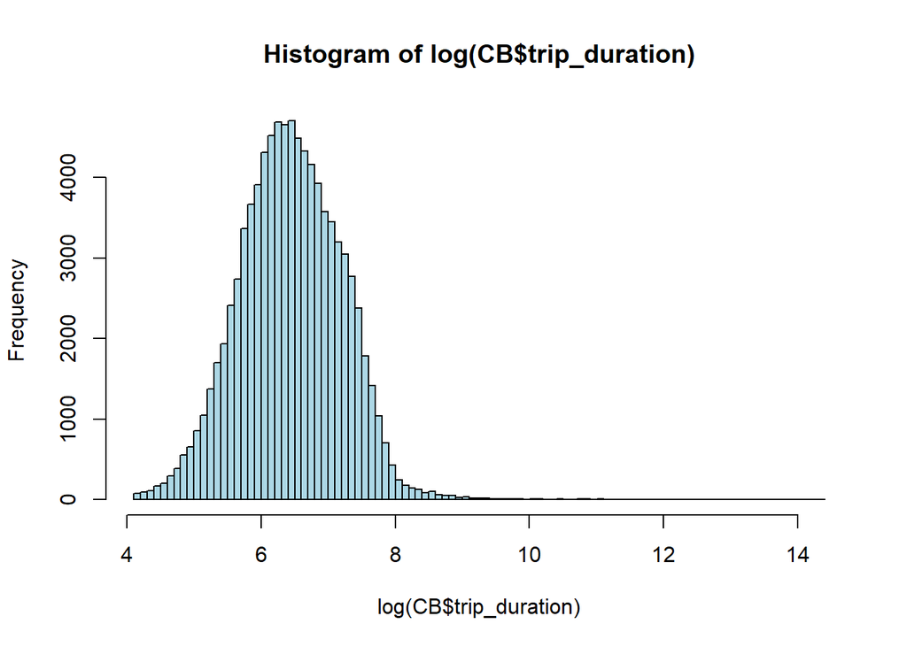

```r
hist(log(CB$trip_duration),col='lightblue', breaks=100)
```

It may be easier to think of trip duration in other units (i.e., minutes, hours, or days) rather than in seconds, so lets create such variables. Also, let’s confirm that the value shown (in seconds) is consistent with the difference between the start time and the end time:

#### Summary of trip durations before censoring/truncation:

```r
#express trip duration in seconds, minutes, hours, days
# note: we needed to fix the November daylight savings problem to eliminate negative trip times

#### Seconds
CB$trip_duration_s = as.numeric(CB$e_time - CB$s_time,"secs")
print("Seconds:")
```

```
## [1] "Seconds:"
```

```r
summary(CB$trip_duration_s)
```

```
##    Min. 1st Qu.  Median    Mean 3rd Qu.    Max.
##      60     375     621     912    1065 1688083
```

```r
#### Minutes
CB$trip_duration_m = as.numeric(CB$e_time - CB$s_time,"mins")
print("Minutes")
```

```
## [1] "Minutes"
```

```r
summary(CB$trip_duration_m)
```

```
##     Min.  1st Qu.   Median     Mean  3rd Qu.     Max.
##     1.00     6.25    10.35    15.20    17.75 28134.72
```

```r
#### Hours
CB$trip_duration_h = as.numeric(CB$e_time - CB$s_time,"hours")
print("Hours")
```

```
## [1] "Hours"
```

```r
summary(CB$trip_duration_h)
```

```
##     Min.  1st Qu.   Median     Mean  3rd Qu.     Max.
##   0.0167   0.1042   0.1725   0.2533   0.2958 468.9119
```

```r
#### Days
CB$trip_duration_d = as.numeric(CB$e_time - CB$s_time,"days")
summary(CB$trip_duration_d)
```

```
##      Min.   1st Qu.    Median      Mean   3rd Qu.      Max.
##  0.000694  0.004340  0.007188  0.010556  0.012326 19.537998
```

```r
print("Days")
```

```
## [1] "Days"
```

```r
sum(CB$trip_duration_h>6)
```

```
## [1] 79
```

Let’s assume that nobody would rent a bicycle for more than a specified timelimit, and drop the records which exceed this:

```r
total_rows=dim(CB)[1]
print(paste("Initial number of trips: ", total_rows))
```

```
## [1] "Initial number of trips:  90370"
```

```r
# choose only trips that were at most 3 hrs, as longer trips may reflect an error
# remove long trips from the data set -- something may be wrong (e.g., the system failed to properly record the return of a bike)
longtripthreshold_s = 60 * 60 *3  # 10800 seconds = 180 minutes = 2 hours
longtripthreshold_m = longtripthreshold_s / 60
longtripthreshold_h = longtripthreshold_m / 60

long_trips <- CB %>% filter(trip_duration_s > longtripthreshold_s)
num_long_trips_removed = dim(long_trips)[1]
pct_long_trips_removed = round(100*num_long_trips_removed / total_rows, 3)

CB <- CB %>% filter(trip_duration <= longtripthreshold_s)
reduced_rows = dim(CB)[1]

print(paste0("Removed ", num_long_trips_removed, " trips (", pct_long_trips_removed, "%) of longer than ", longtripthreshold_h, " hours."))
```

```
## [1] "Removed 157 trips (0.174%) of longer than 3 hours."
```

```r
print(paste0("Remaining number of trips: ", reduced_rows))
```

```
## [1] "Remaining number of trips: 90213"
```

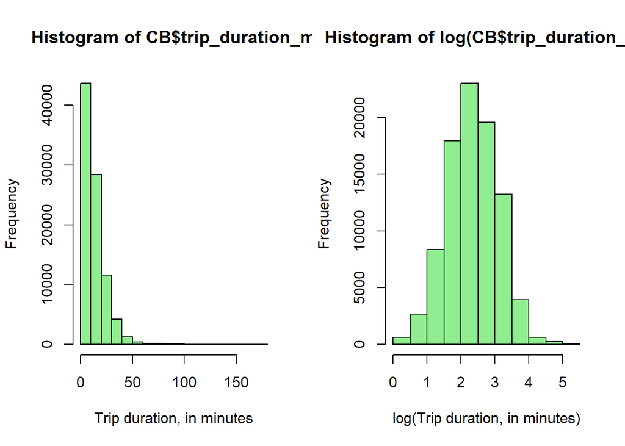

```r
par(mfrow=c(1,2))
hist(CB$trip_duration_m, col="lightgreen",  xlab="Trip duration, in minutes")
hist(log(CB$trip_duration_m), col="lightgreen",  xlab="log(Trip duration, in minutes)")
```

### Examine birth year

The birth year for some users is as old as 1885, which is not possible.

```r
summary(CB$birth_year)
```

```
##    Min. 1st Qu.  Median    Mean 3rd Qu.    Max.    NA's
##    1885    1969    1981    1978    1988    2003    5828
```

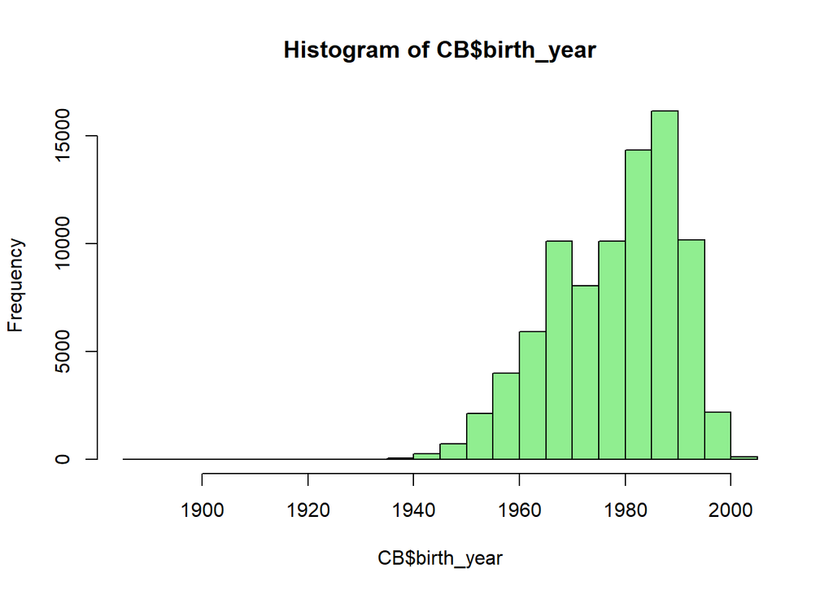

```r
hist(CB$birth_year, col="lightgreen")
```

#### Remove trips associated with very old users

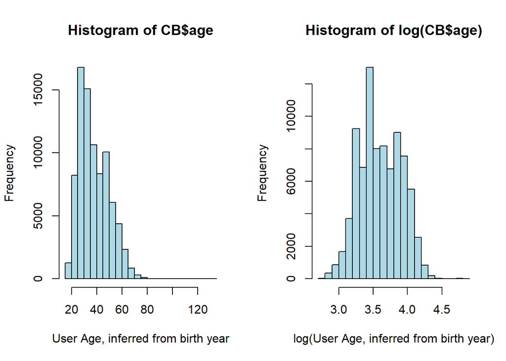

```r
# Deduce age from trip date and birth year
#library(lubridate) #loaded above
CB$age <- year(CB$s_time) - CB$birth_year

par(mfrow=c(1,2))
hist(CB$age, col="lightblue",  xlab="User Age, inferred from birth year")
hist(log(CB$age), col="lightblue",  xlab="log(User Age, inferred from birth year)")
```

```r
# choose only trips where the user was born after a certain year,  as older users may reflect an error
age_threshhold = 90


aged_trips <- CB %>% filter(age > age_threshhold)
num_aged_trips_removed = dim(aged_trips)[1]
pct_aged_trips_removed = round(100*num_aged_trips_removed / total_rows, 3)

CB <- CB %>% filter(age <= age_threshhold)
reduced_rows = dim(CB)[1]

print(paste0("Removed ", num_aged_trips_removed, " trips (", pct_aged_trips_removed, "%) of users older than ", age_threshhold, " years."))
```

```
## [1] "Removed 40 trips (0.044%) of users older than 90 years."
```

```r
print(paste0("Remaining number of trips: ", reduced_rows))
```

```
## [1] "Remaining number of trips: 84345"
```

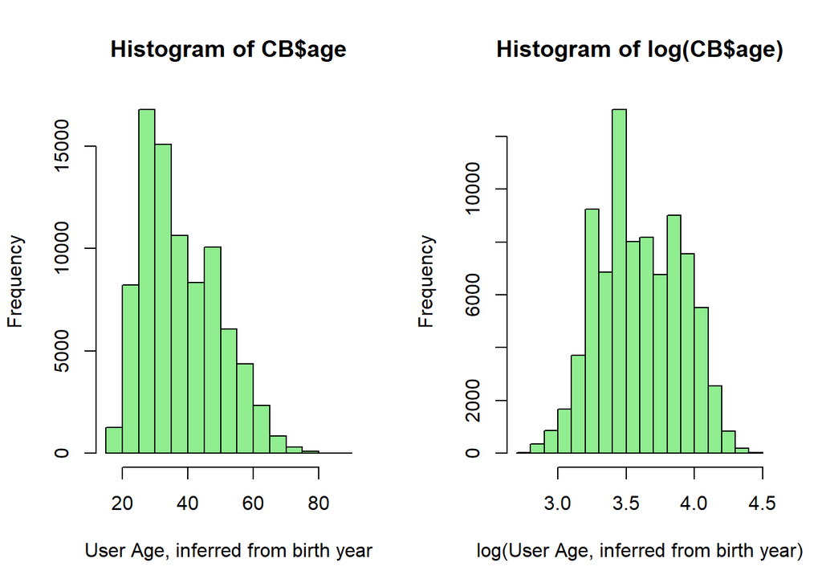

```r
par(mfrow=c(1,2))
hist(CB$age, col="lightgreen",  xlab="User Age, inferred from birth year")
hist(log(CB$age), col="lightgreen",  xlab="log(User Age, inferred from birth year)")
```

#### Compute distance between start and end stations

This is straight-line distance – it doesn’t incorporate an actual route.  
There are services (e.g., from Google) which can compute and measure a recommended bicycle route between points, but use of such services requires a subscription and incurs a cost.

```r
# Compute the distance between start and end stations
s_lat_long <- CB %>% select(c(s_lat,s_long)) %>%  as.matrix
e_lat_long <- CB %>% select(c(e_lat,e_long)) %>%  as.matrix
#library(sp) # loaded above
CB$distance_km <- spDists(s_lat_long, e_lat_long, longlat=T, diagonal = TRUE)
```

```r
# There is a time-based usage fee for rides longer than an initial period.
# For user_type=Subscriber, the fee is $2.50 per 15 minutes following an initial free 45 minutes.
# For user_type=Customer, the fee is $4.00 per 15 minutes following an initial free 30 minutes.
# There are some cases where the user type is not specified (we have relabeled as "UNKNOWN")


CB$trip_fee[CB$user_type=="Subscriber"] <- 2.50 * (ceiling(
  CB$trip_duration_m[CB$user_type=="Subscriber"]  / 15)-3)  # first 45 minutes are free
CB$trip_fee[CB$user_type=="Customer"]   <- 4.00 * (ceiling(
  CB$trip_duration_m[CB$user_type=="Customer"]  / 15)-2)  # first 30 minutes are free
CB$trip_fee[CB$trip_fee<0] <- 0   # fee is non-negative
```

#### Summary of trip durations AFTER censoring/truncation:

```r
#express trip duration in seconds, minutes, hours, days
# note: we needed to fix the November daylight savings problem to eliminate negative trip times

#### Seconds
CB$trip_duration_s = as.numeric(CB$e_time - CB$s_time,"secs")
print("Seconds:")
```

```
## [1] "Seconds:"
```

```r
summary(CB$trip_duration_s)
```

```
##    Min. 1st Qu.  Median    Mean 3rd Qu.    Max.
##    60.0   364.0   594.5   778.2   997.8 10617.5
```

```r
#### Minutes
CB$trip_duration_m = as.numeric(CB$e_time - CB$s_time,"mins")
print("Minutes")
```

```
## [1] "Minutes"
```

```r
summary(CB$trip_duration_m)
```

```
##    Min. 1st Qu.  Median    Mean 3rd Qu.    Max.
##   1.000   6.067   9.908  12.970  16.630 176.959
```

```r
#### Hours
CB$trip_duration_h = as.numeric(CB$e_time - CB$s_time,"hours")
print("Hours")
```

```
## [1] "Hours"
```

```r
summary(CB$trip_duration_h)
```

```
##    Min. 1st Qu.  Median    Mean 3rd Qu.    Max.
## 0.01667 0.10111 0.16514 0.21616 0.27716 2.94931
```

```r
#### Days
CB$trip_duration_d = as.numeric(CB$e_time - CB$s_time,"days")
summary(CB$trip_duration_d)
```

```
##      Min.   1st Qu.    Median      Mean   3rd Qu.      Max.
## 0.0006944 0.0042130 0.0068807 0.0090068 0.0115485 0.1228879
```

```r
print("Days")
```

```
## [1] "Days"
```

```r
sum(CB$trip_duration_h>6)
```

```
## [1] 0
```

#### Make a smaller dataset, numeric, without multicollinearities, for correlation calculations

```r
# extract selected fields
CBlite  <- select(CB, c(trip_duration, trip_fee, distance_km,
                        s_station_id, s_lat, s_long,
                        e_station_id, e_lat, e_long,
                        user_type, gender, age))

#make numeric variables
CBlite$user_type <- as.integer(CBlite$user_type)
CBlite$gender <- as.integer(CBlite$gender)

# function to revert factor back to its numeric levels
as.numeric.factor <- function(x) {as.numeric(levels(x))[x]}

CBlite$s_station_id <- as.numeric.factor(CBlite$s_station_id)
CBlite$e_station_id <- as.numeric.factor(CBlite$e_station_id)
```

### compute correlations

```r
#library(Hmisc) #loaded above
res2<-rcorr(as.matrix(CBlite))
respearson=rcorr(as.matrix(CBlite),type = "pearson")
resspearman=rcorr(as.matrix(CBlite),type = "spearman")
res3 <- cor(as.matrix(CBlite))
```